# WHO-life-expectancy-analysis

2026-11-04

```r
knitr::opts_chunk$set(echo = TRUE)
```

```r
library(shiny)
library(bslib)
library(ggplot2)
library(patchwork)
library(car)
library(DT)
Life_Expectancy_Data <- read.csv("Life-Expectancy-Data-Updated.csv")
```

# Data exploration

First, we want to see the structure of our data. What variables do we have, for which countries, etc. Then we will check if the data has any empty, missing or weird entries. Lastly, we will give some Rshiny tools so you can explore the data yourself.

## Data structure

**What columns do we have? How many rows?**

```r
colnames(Life_Expectancy_Data)
```

```
##  [1] "Country"                     "Region"
##  [3] "Year"                        "Infant_deaths"
##  [5] "Under_five_deaths"           "Adult_mortality"
##  [7] "Alcohol_consumption"         "Hepatitis_B"
##  [9] "Measles"                     "BMI"
## [11] "Polio"                       "Diphtheria"
## [13] "Incidents_HIV"               "GDP_per_capita"
## [15] "Population_mln"              "Thinness_ten_nineteen_years"
## [17] "Thinness_five_nine_years"    "Schooling"
## [19] "Economy_status_Developed"    "Economy_status_Developing"
## [21] "Life_expectancy"
```

```r
paste(nrow(Life_Expectancy_Data), "rows")
```

```
## [1] "2864 rows"
```

There are 21 columns and 2864 rows. Important to note for some columns:  
* Hepatitis B, Measles, Polio and Diphteria show % of *vaccination* coverage, not incidence  
Further information on what these columns represent is explained on the Kaggle page under Data sources:  
[Kaggle data sources](https://www.kaggle.com/datasets/lashagoch/life-expectancy-who-updated/data).

**How are the rows structured?**

For example, how many countries are there? How many years?  
And do these explain the number of rows seen?

```r
row_explain = c(Countries = 0, Years = 0, Product = 0, Nrows = nrow(Life_Expectancy_Data))
row_explain["Countries"] = length(unique(Life_Expectancy_Data$Country))
row_explain["Years"] = length(unique(Life_Expectancy_Data$Year))
row_explain["Product"] = row_explain["Countries"] * row_explain["Years"]
row_explain
```

```
## Countries     Years   Product     Nrows
##       179        16      2864      2864
```

As you can see, this seems to indicate that all 179 countries occur for all 16 years to explain the 2864 rows in the dataset.

Which specific years are included?

```r
years = unique(Life_Expectancy_Data$Year)
years = years[order(years)]
years
```

```
##  [1] 2000 2001 2002 2003 2004 2005 2006 2007 2008 2009 2010 2011 2012 2013 2014
## [16] 2015
```

So from 2000 to 2015

However, we will further validate this structure:  
How many countries are present 16 times, so once for each year?

```r
sum(table(Life_Expectancy_Data$Country) == 16)
```

```
## [1] 179
```

This all seems right, so the years and countries are used consistently!

**What data types are present?**

```r
str(Life_Expectancy_Data)
```

```
## 'data.frame':    2864 obs. of  21 variables:
##  $ Country                    : chr  "Turkiye" "Spain" "India" "Guyana" ...
##  $ Region                     : chr  "Middle East" "European Union" "Asia" "South America" ...
##  $ Year                       : int  2015 2015 2007 2006 2012 2006 2015 2000 2001 2008 ...
##  $ Infant_deaths              : num  11.1 2.7 51.5 32.8 3.4 9.8 6.6 8.7 22 15.3 ...
##  $ Under_five_deaths          : num  13 3.3 67.9 40.5 4.3 11.2 8.2 10.1 26.1 17.8 ...
##  $ Adult_mortality            : num  105.8 57.9 201.1 222.2 58 ...
##  $ Alcohol_consumption        : num  1.32 10.35 1.57 5.68 2.89 ...
##  $ Hepatitis_B                : int  97 97 60 93 97 88 97 88 97 97 ...
##  $ Measles                    : int  65 94 35 74 89 86 97 99 87 92 ...
##  $ BMI                        : num  27.8 26 21.2 25.3 27 26.4 26.2 25.9 27.9 26.5 ...
##  $ Polio                      : int  97 97 67 92 94 89 97 99 97 96 ...
##  $ Diphtheria                 : int  97 97 64 93 94 89 97 99 99 90 ...
##  $ Incidents_HIV              : num  0.08 0.09 0.13 0.79 0.08 0.16 0.08 0.08 0.13 0.43 ...
##  $ GDP_per_capita             : int  11006 25742 1076 4146 33995 9110 9313 8971 3708 2235 ...
##  $ Population_mln             : num  78.53 46.44 1183.21 0.75 7.91 ...
##  $ Thinness_ten_nineteen_years: num  4.9 0.6 27.1 5.7 1.2 2 2.3 2.3 4 2.9 ...
##  $ Thinness_five_nine_years   : num  4.8 0.5 28 5.5 1.1 1.9 2.3 2.3 3.9 3.1 ...
##  $ Schooling                  : num  7.8 9.7 5 7.9 12.8 7.9 12 10.2 9.6 10.9 ...
##  $ Economy_status_Developed   : int  0 1 0 0 1 0 0 1 0 0 ...
##  $ Economy_status_Developing  : int  1 0 1 1 0 1 1 0 1 1 ...
##  $ Life_expectancy            : num  76.5 82.8 65.4 67 81.7 78.2 71.2 71.2 71.9 68.7 ...
```

The Economy status developing column contains only ones and zeros, so True and False. It is the inverse of the developed column.  
The Country and Region columns contain characters, where Region has 9 possibilies. All other columns are integers or numeric.

**What is the life expectancy distribution?**

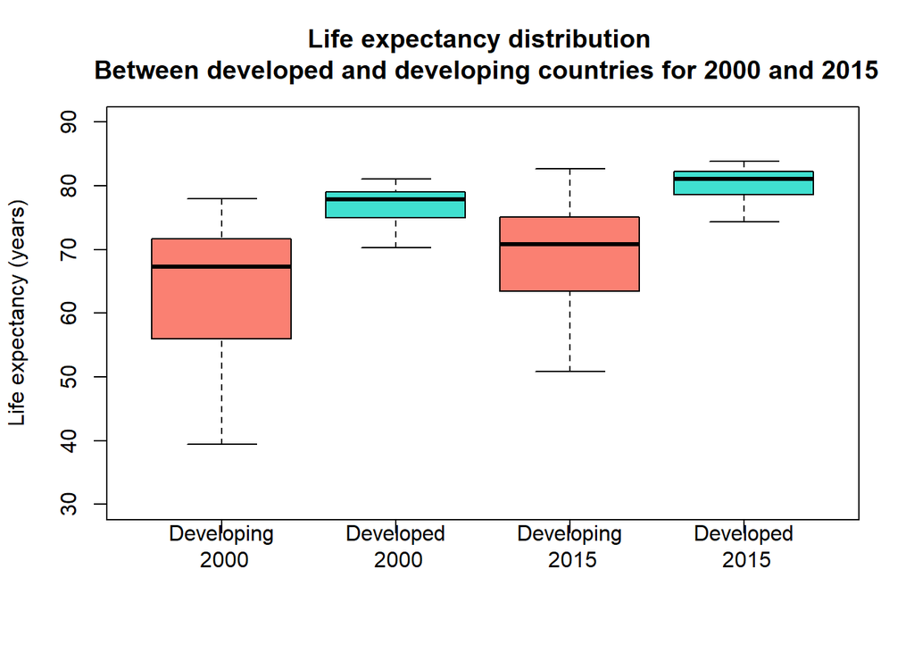

```r
boxplot(Life_Expectancy_Data[Life_Expectancy_Data$Year == 2000 & Life_Expectancy_Data$Economy_status_Developing == T,"Life_expectancy"],
        Life_Expectancy_Data[Life_Expectancy_Data$Year == 2000 & Life_Expectancy_Data$Economy_status_Developing == F,"Life_expectancy"],
        Life_Expectancy_Data[Life_Expectancy_Data$Year == 2015 & Life_Expectancy_Data$Economy_status_Developing == T,"Life_expectancy"],
        Life_Expectancy_Data[Life_Expectancy_Data$Year == 2015 & Life_Expectancy_Data$Economy_status_Developing == F,"Life_expectancy"],
        main = "Life expectancy distribution \n Between developed and developing countries for 2000 and 2015",
        names = c("Developing\n 2000", "Developed\n 2000", "Developing\n 2015", "Developed\n 2015"),
        col = c("salmon", "turquoise"),
        ylab = "Life expectancy (years)",
        ylim = c(30,90))
```

**How many countries are either developed or developing?**

```r
develop = c(Developed = 0, Developing =  0, Total = 0)
develop["Developed"] = sum(Life_Expectancy_Data$Economy_status_Developed == T) / 16
develop["Developing"] = sum(Life_Expectancy_Data$Economy_status_Developed == F) / 16
develop["Total"] = develop[1] + develop[2]
develop
```

```
##  Developed Developing      Total
##         37        142        179
```

**Are there empty values or NA values?**

```r
empty = c(Empty = 0, NAs = 0)
# how many NAs?
empty["NAs"] = sum(is.na(Life_Expectancy_Data))
empty["Empty"] = sum(Life_Expectancy_Data == "")
empty
```

```
## Empty   NAs
##     0     0
```

All together, we now understand the data structure and have seen that it is complete. It is important to keep in mind that each country occurs 16 times, once for each year.

## Visualisation:

**Here we will make a shiny application that easily lets the user explore life expectancy over time for a selected country.**

```r
ui = page_sidebar(
  title = "Life expectancy over time",
  sidebar = sidebar(
    "This graph allows you to select any country in the dataset and then plot
    its life expectancy over time",
    selectInput("country", "Select a country", choices = unique(Life_Expectancy_Data$Country))
  ),
  card(
    card_header("Life expectancy over time plot"),
    plotOutput("plot")
  )
)

server = function(input, output){
  output$plot = renderPlot({
    x = Life_Expectancy_Data[Life_Expectancy_Data$Country == input$country, "Year"]
    y = Life_Expectancy_Data[Life_Expectancy_Data$Country == input$country, "Life_expectancy"]
    plot(
      x,y,
      main = paste("Life expectancy over time for", input$country),
      xlab = "Time (years)",
      ylab = "Life expectancy"
    )
  })
}

shinyApp(ui, server)
```

Shiny applications not supported in static R Markdown documents

**Here we will make an interactive table using Rshiny**

```r
ui = page_sidebar(
  title = "Interactive Life expectancy table",
  sidebar = sidebar(
    "Here you can interactively inspect the WHO Life Expectancy data"
  ),
  card(
    card_header("WHO Life Expectancy data"),
    DT::dataTableOutput("table")
  )
)

server = function(input,output){
  output$table = DT::renderDataTable(DT::datatable({
    data = Life_Expectancy_Data
    data
  }))
}

shinyApp(ui, server)
```

Shiny applications not supported in static R Markdown documents

## Outlier for GDP analysis Laziren

We found an outlier in the GDP data, Eritrea is way too high in 2015:

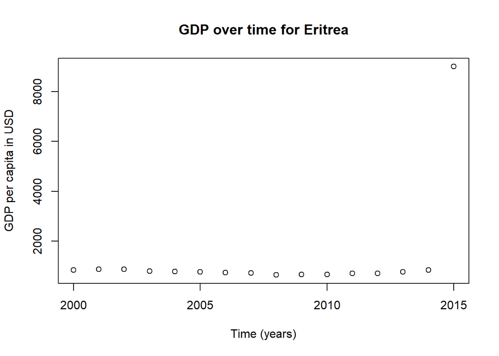

```r
x = Life_Expectancy_Data[Life_Expectancy_Data$Country == "Eritrea", "Year"]
y = Life_Expectancy_Data[Life_Expectancy_Data$Country == "Eritrea", "GDP_per_capita"]
plot(x,y,
     main = "GDP over time for Eritrea",
     xlab = "Time (years)",
     ylab = "GDP per capita in USD"
     )
```

## Analysis Wietske

```r
educationModel <- lm(
  Life_expectancy ~ Schooling + Infant_deaths + Under_five_deaths + GDP_per_capita + Hepatitis_B + Measles + Population_mln +
    Thinness_ten_nineteen_years +
    Thinness_five_nine_years +
    Adult_mortality + Incidents_HIV +
    BMI + Alcohol_consumption +
    Polio + Diphtheria + Economy_status_Developed,
  data = Life_Expectancy_Data
)
educationModel
```

```
##
## Call:
## lm(formula = Life_expectancy ~ Schooling + Infant_deaths + Under_five_deaths +
##     GDP_per_capita + Hepatitis_B + Measles + Population_mln +
##     Thinness_ten_nineteen_years + Thinness_five_nine_years +
##     Adult_mortality + Incidents_HIV + BMI + Alcohol_consumption +
##     Polio + Diphtheria + Economy_status_Developed, data = Life_Expectancy_Data)
##
## Coefficients:
##                 (Intercept)                    Schooling
##                   8.452e+01                    9.531e-02
##               Infant_deaths            Under_five_deaths
##                  -4.791e-02                   -5.603e-02
##              GDP_per_capita                  Hepatitis_B
##                   2.548e-05                   -7.691e-03
##                     Measles               Population_mln
##                   1.390e-03                   -1.342e-04
## Thinness_ten_nineteen_years     Thinness_five_nine_years
##                  -3.368e-02                    2.573e-03
##             Adult_mortality                Incidents_HIV
##                  -4.829e-02                    9.465e-02
##                         BMI          Alcohol_consumption
##                  -1.455e-01                    6.417e-02
##                       Polio                   Diphtheria
##                   2.300e-03                    8.558e-04
##    Economy_status_Developed
##                   6.442e-01
```

```r
summary(educationModel)
```

```
##
## Call:
## lm(formula = Life_expectancy ~ Schooling + Infant_deaths + Under_five_deaths +
##     GDP_per_capita + Hepatitis_B + Measles + Population_mln +
##     Thinness_ten_nineteen_years + Thinness_five_nine_years +
##     Adult_mortality + Incidents_HIV + BMI + Alcohol_consumption +
##     Polio + Diphtheria + Economy_status_Developed, data = Life_Expectancy_Data)
##
## Residuals:
##     Min      1Q  Median      3Q     Max
## -4.7613 -0.8923 -0.0699  0.8606  8.0965
##
## Coefficients:
##                               Estimate Std. Error t value Pr(>|t|)
## (Intercept)                  8.452e+01  6.148e-01 137.481  < 2e-16 ***
## Schooling                    9.531e-02  1.681e-02   5.669 1.58e-08 ***
## Infant_deaths               -4.791e-02  6.180e-03  -7.752 1.25e-14 ***
## Under_five_deaths           -5.603e-02  3.841e-03 -14.588  < 2e-16 ***
## GDP_per_capita               2.548e-05  2.289e-06  11.130  < 2e-16 ***
## Hepatitis_B                 -7.691e-03  2.558e-03  -3.006  0.00267 **
## Measles                      1.390e-03  1.718e-03   0.809  0.41835
## Population_mln              -1.342e-04  2.000e-04  -0.671  0.50229
## Thinness_ten_nineteen_years -3.368e-02  1.715e-02  -1.964  0.04962 *
## Thinness_five_nine_years     2.573e-03  1.682e-02   0.153  0.87845
## Adult_mortality             -4.829e-02  6.204e-04 -77.831  < 2e-16 ***
## Incidents_HIV                9.465e-02  1.819e-02   5.205 2.08e-07 ***
## BMI                         -1.455e-01  1.915e-02  -7.600 3.99e-14 ***
## Alcohol_consumption          6.417e-02  9.914e-03   6.473 1.13e-10 ***
## Polio                        2.300e-03  5.845e-03   0.393  0.69404
## Diphtheria                   8.558e-04  5.904e-03   0.145  0.88476
## Economy_status_Developed     6.442e-01  1.082e-01   5.954 2.93e-09 ***
## ---
## Signif. codes:  0 '***' 0.001 '**' 0.01 '*' 0.05 '.' 0.1 ' ' 1
##
## Residual standard error: 1.361 on 2847 degrees of freedom
## Multiple R-squared:  0.9792, Adjusted R-squared:  0.9791
## F-statistic:  8368 on 16 and 2847 DF,  p-value: < 2.2e-16
```

```r
standardizedFullModel <- lm(
  scale(Life_expectancy) ~
    scale(Schooling) +
    scale(Infant_deaths) +
    scale(Under_five_deaths) +
    scale(GDP_per_capita) +
    scale(Hepatitis_B) +
    scale(Measles) +
    scale(Population_mln) +
    scale(Thinness_ten_nineteen_years) +
    scale(Thinness_five_nine_years) +
    scale(Adult_mortality) +
    scale(Incidents_HIV) +
    scale(BMI) +
    scale(Alcohol_consumption) +
    scale(Polio) +
    scale(Diphtheria) +
    scale(Economy_status_Developed),
  data = Life_Expectancy_Data
)

summary(standardizedFullModel)
```

```
##
## Call:
## lm(formula = scale(Life_expectancy) ~ scale(Schooling) + scale(Infant_deaths) +
##     scale(Under_five_deaths) + scale(GDP_per_capita) + scale(Hepatitis_B) +
##     scale(Measles) + scale(Population_mln) + scale(Thinness_ten_nineteen_years) +
##     scale(Thinness_five_nine_years) + scale(Adult_mortality) +
##     scale(Incidents_HIV) + scale(BMI) + scale(Alcohol_consumption) +
##     scale(Polio) + scale(Diphtheria) + scale(Economy_status_Developed),
##     data = Life_Expectancy_Data)
##
## Residuals:
##      Min       1Q   Median       3Q      Max
## -0.50622 -0.09487 -0.00744  0.09149  0.86081
##
## Coefficients:
##                                      Estimate Std. Error t value Pr(>|t|)
## (Intercept)                         5.376e-16  2.704e-03   0.000  1.00000
## scale(Schooling)                    3.214e-02  5.669e-03   5.669 1.58e-08 ***
## scale(Infant_deaths)               -1.403e-01  1.809e-02  -7.752 1.25e-14 ***
## scale(Under_five_deaths)           -2.655e-01  1.820e-02 -14.588  < 2e-16 ***
## scale(GDP_per_capita)               4.588e-02  4.122e-03  11.130  < 2e-16 ***
## scale(Hepatitis_B)                 -1.308e-02  4.351e-03  -3.006  0.00267 **
## scale(Measles)                      2.758e-03  3.408e-03   0.809  0.41835
## scale(Population_mln)              -1.947e-03  2.902e-03  -0.671  0.50229
## scale(Thinness_ten_nineteen_years) -1.589e-02  8.091e-03  -1.964  0.04962 *
## scale(Thinness_five_nine_years)     1.238e-03  8.094e-03   0.153  0.87845
## scale(Adult_mortality)             -5.899e-01  7.580e-03 -77.831  < 2e-16 ***
## scale(Incidents_HIV)                2.397e-02  4.604e-03   5.205 2.08e-07 ***
## scale(BMI)                         -3.394e-02  4.466e-03  -7.600 3.99e-14 ***
## scale(Alcohol_consumption)          2.717e-02  4.197e-03   6.473 1.13e-10 ***
## scale(Polio)                        3.687e-03  9.372e-03   0.393  0.69404
## scale(Diphtheria)                   1.413e-03  9.751e-03   0.145  0.88476
## scale(Economy_status_Developed)     2.774e-02  4.659e-03   5.954 2.93e-09 ***
## ---
## Signif. codes:  0 '***' 0.001 '**' 0.01 '*' 0.05 '.' 0.1 ' ' 1
##
## Residual standard error: 0.1447 on 2847 degrees of freedom
## Multiple R-squared:  0.9792, Adjusted R-squared:  0.9791
## F-statistic:  8368 on 16 and 2847 DF,  p-value: < 2.2e-16
```

```r
vif(standardizedFullModel)
```

```
##                   scale(Schooling)               scale(Infant_deaths)
##                           4.394280                          44.761523
##           scale(Under_five_deaths)              scale(GDP_per_capita)
##                          45.290335                           2.323248
##                 scale(Hepatitis_B)                     scale(Measles)
##                           2.588503                           1.587821
##              scale(Population_mln) scale(Thinness_ten_nineteen_years)
##                           1.151908                           8.950249
##    scale(Thinness_five_nine_years)             scale(Adult_mortality)
##                           8.958574                           7.856021
##               scale(Incidents_HIV)                         scale(BMI)
##                           2.898779                           2.727398
##         scale(Alcohol_consumption)                       scale(Polio)
##                           2.408911                          12.010371
##                  scale(Diphtheria)    scale(Economy_status_Developed)
##                          13.001018                           2.967789
```

```r
reducedModel <- lm(
  Life_expectancy ~ Schooling + Under_five_deaths +
    GDP_per_capita + Hepatitis_B + Measles +
    Population_mln + Thinness_ten_nineteen_years +
    Adult_mortality + Incidents_HIV + BMI +
    Alcohol_consumption + Diphtheria +
    Economy_status_Developed,
  data = Life_Expectancy_Data
)
vif(reducedModel)
```

```
##                   Schooling           Under_five_deaths
##                    4.385718                    7.931688
##              GDP_per_capita                 Hepatitis_B
##                    2.276296                    2.553786
##                     Measles              Population_mln
##                    1.544906                    1.149836
## Thinness_ten_nineteen_years             Adult_mortality
##                    2.002030                    7.797584
##               Incidents_HIV                         BMI
##                    2.852146                    2.657483
##         Alcohol_consumption                  Diphtheria
##                    2.362556                    4.021853
##    Economy_status_Developed
##                    2.926957
```

```r
standardizedReducedModel <- lm(
  scale(Life_expectancy) ~
    scale(Schooling) +
    scale(Under_five_deaths) +
    scale(GDP_per_capita) +
    scale(Hepatitis_B) +
    scale(Measles) +
    scale(Population_mln) +
    scale(Thinness_ten_nineteen_years) +
    scale(Adult_mortality) +
    scale(Incidents_HIV) +
    scale(BMI) +
    scale(Alcohol_consumption) +
    scale(Diphtheria) +
    scale(Economy_status_Developed),
  data = Life_Expectancy_Data
)

summary(standardizedReducedModel)
```

```
##
## Call:
## lm(formula = scale(Life_expectancy) ~ scale(Schooling) + scale(Under_five_deaths) +
##     scale(GDP_per_capita) + scale(Hepatitis_B) + scale(Measles) +
##     scale(Population_mln) + scale(Thinness_ten_nineteen_years) +
##     scale(Adult_mortality) + scale(Incidents_HIV) + scale(BMI) +
##     scale(Alcohol_consumption) + scale(Diphtheria) + scale(Economy_status_Developed),
##     data = Life_Expectancy_Data)
##
## Residuals:
##      Min       1Q   Median       3Q      Max
## -0.54006 -0.09518 -0.00670  0.09295  0.96901
##
## Coefficients:
##                                      Estimate Std. Error t value Pr(>|t|)
## (Intercept)                         5.256e-16  2.731e-03   0.000   1.0000
## scale(Schooling)                    3.193e-02  5.721e-03   5.581 2.61e-08 ***
## scale(Under_five_deaths)           -3.943e-01  7.693e-03 -51.247  < 2e-16 ***
## scale(GDP_per_capita)               5.010e-02  4.121e-03  12.157  < 2e-16 ***
## scale(Hepatitis_B)                 -9.361e-03  4.365e-03  -2.144   0.0321 *
## scale(Measles)                      4.135e-03  3.395e-03   1.218   0.2233
## scale(Population_mln)              -2.360e-03  2.929e-03  -0.806   0.4205
## scale(Thinness_ten_nineteen_years) -1.706e-02  3.865e-03  -4.413 1.06e-05 ***
## scale(Adult_mortality)             -5.947e-01  7.628e-03 -77.959  < 2e-16 ***
## scale(Incidents_HIV)                2.786e-02  4.613e-03   6.038 1.76e-09 ***
## scale(BMI)                         -3.451e-02  4.453e-03  -7.750 1.27e-14 ***
## scale(Alcohol_consumption)          3.168e-02  4.199e-03   7.544 6.08e-14 ***
## scale(Diphtheria)                   3.362e-03  5.478e-03   0.614   0.5394
## scale(Economy_status_Developed)     3.120e-02  4.673e-03   6.675 2.96e-11 ***
## ---
## Signif. codes:  0 '***' 0.001 '**' 0.01 '*' 0.05 '.' 0.1 ' ' 1
##
## Residual standard error: 0.1462 on 2850 degrees of freedom
## Multiple R-squared:  0.9787, Adjusted R-squared:  0.9786
## F-statistic: 1.009e+04 on 13 and 2850 DF,  p-value: < 2.2e-16
```

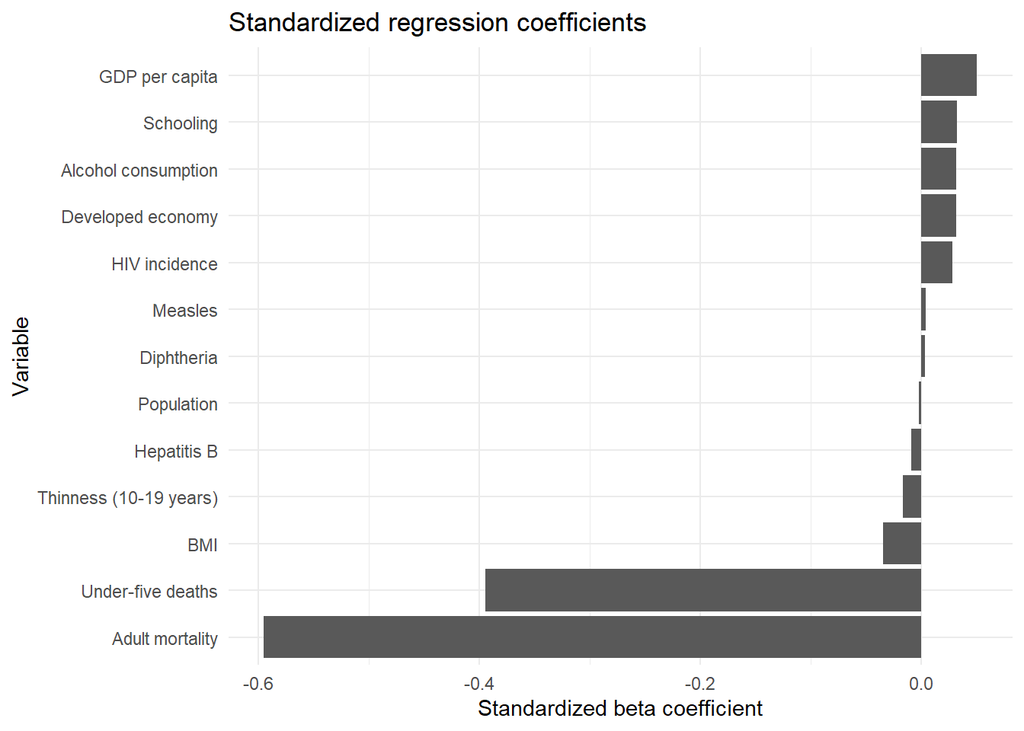

```r
beta_data <- data.frame(
  Variable = c(
    "Adult mortality",
    "Under-five deaths",
    "GDP per capita",
    "BMI",
    "Alcohol consumption",
    "Developed economy",
    "Schooling",
    "HIV incidence",
    "Thinness (10-19 years)",
    "Hepatitis B",
    "Diphtheria",
    "Measles",
    "Population"
  ),
  Beta = c(
    -0.5947, -0.3943, 0.05010, -0.03451,
    0.03168, 0.03120, 0.03193, 0.02786,
    -0.01706, -0.009361, 0.003362,
    0.004135, -0.002360
  )
)

ggplot(beta_data, aes(x = reorder(Variable, Beta), y = Beta)) +
  geom_col() +
  coord_flip() +
  labs(
    x = "Variable",
    y = "Standardized beta coefficient",
    title = "Standardized regression coefficients"
  ) +
  theme_minimal()
```

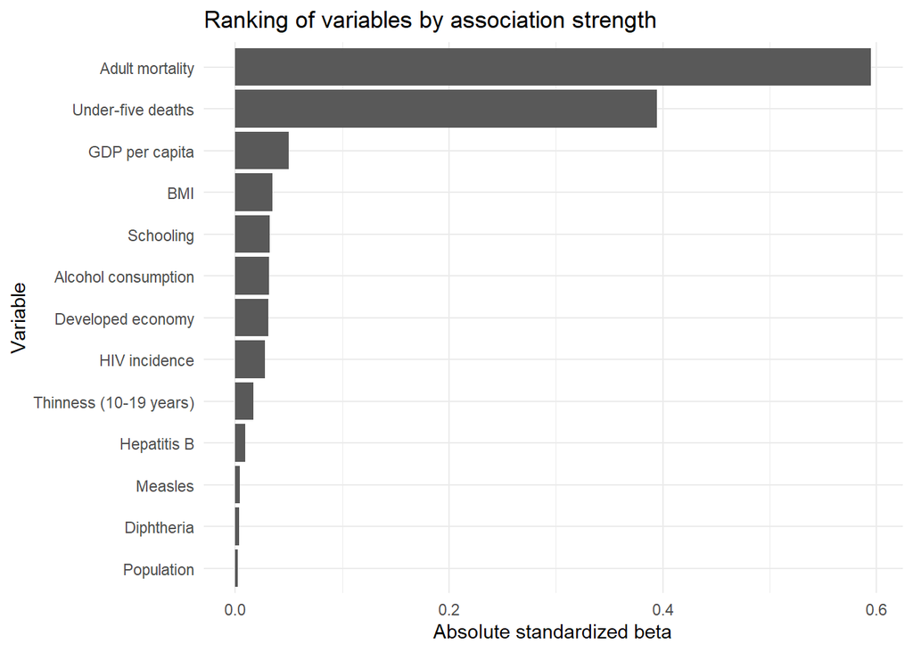

```r
ggplot(beta_data,
       aes(x = reorder(Variable, abs(Beta)), y = abs(Beta))) +
  geom_col() +
  coord_flip() +
  labs(
    x = "Variable",
    y = "Absolute standardized beta",
    title = "Ranking of variables by association strength"
  ) + theme_minimal()
```

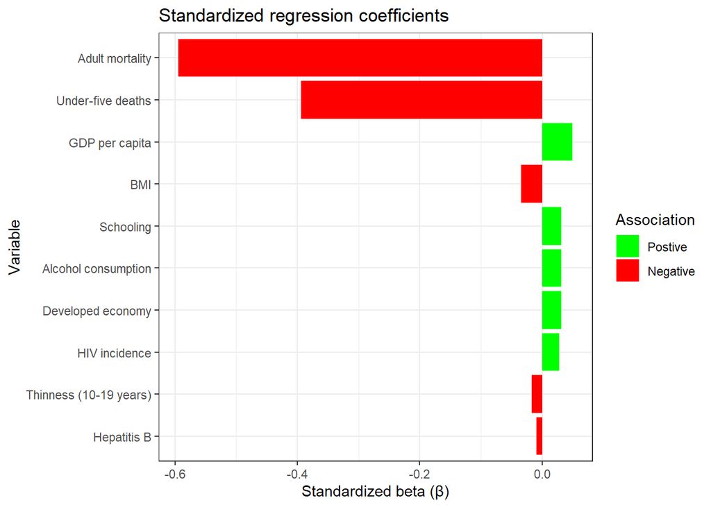

```r
Beta_data_significant <- data.frame(
  Variable = c(
    "Adult mortality",
    "Under-five deaths",
    "GDP per capita",
    "BMI",
    "Alcohol consumption",
    "Developed economy",
    "Schooling",
    "HIV incidence",
    "Thinness (10-19 years)",
    "Hepatitis B"
  ),
  Beta = c(
    -0.5947, -0.3943, 0.05010, -0.03451,
    0.03168, 0.03120, 0.03193, 0.02786,
    -0.01706, -0.009361
  )
)

ggplot(Beta_data_significant,
       aes(x = reorder(Variable, abs(Beta)),
           y = Beta,
           fill = Beta < 0)) +
  geom_col() +
  coord_flip() +
  scale_fill_manual(
    values = c("TRUE" = "red", "FALSE" = "green"),
    labels = c("Postive", "Negative")
  ) +
  labs(
    x = "Variable",
    y = "Standardized beta (β)",
    title = "Standardized regression coefficients",
    fill = "Association"
  ) +
  theme_bw()
```

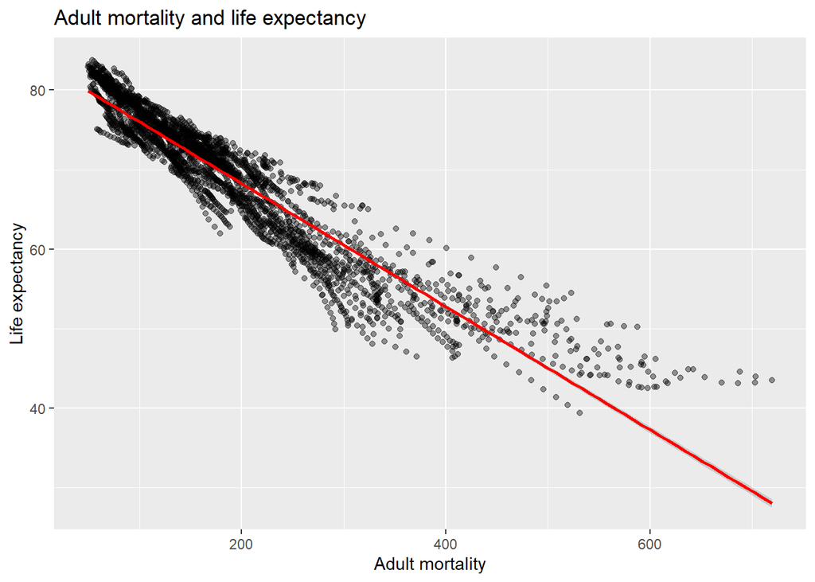

```r
p1 <- ggplot(Life_Expectancy_Data,
       aes(x = Adult_mortality, y = Life_expectancy)) +
  geom_point(alpha = 0.4) +
  geom_smooth(color = 'red', method = "lm", se = TRUE) +
  labs(x = "Adult mortality",
       y = "Life expectancy",
       title = "Adult mortality and life expectancy")
p1
```

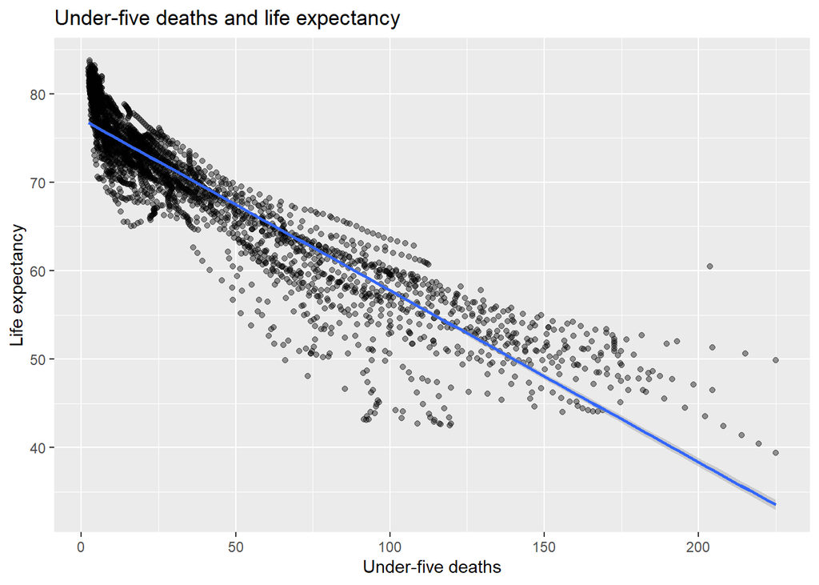

```r
p2 <- ggplot(Life_Expectancy_Data,
       aes(x = Under_five_deaths, y = Life_expectancy)) +
  geom_point(alpha = 0.4) +
  geom_smooth(method = "lm", se = TRUE) +
  labs(x = "Under-five deaths",
       y = "Life expectancy",
       title = "Under-five deaths and life expectancy")
p2
```

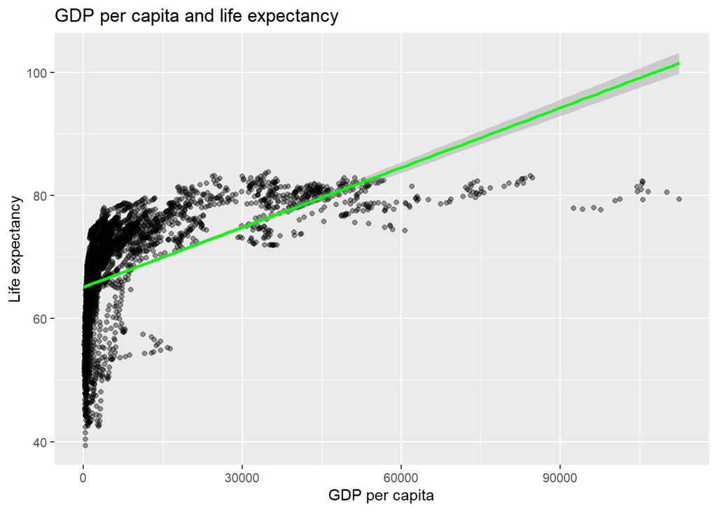

```r
p3 <- ggplot(Life_Expectancy_Data,
       aes(x = GDP_per_capita, y = Life_expectancy)) +
  geom_point(alpha = 0.4) +
  geom_smooth(color = 'green', method = "lm", se = TRUE) +
  labs(x = "GDP per capita",
       y = "Life expectancy",
       title = "GDP per capita and life expectancy")
p3
```

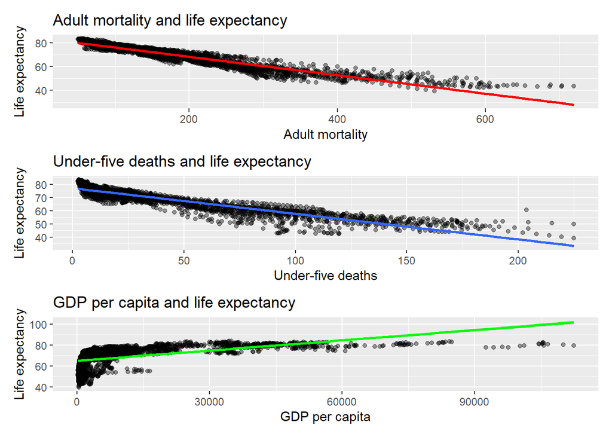

```r
combinedplot <- p1/ p2/ p3
combinedplot
```

[output not shown]